# STged: Precise gene expression Deconvolution for simulation data

Jia-Juan Tu

##Set the size of the figures

## Load function

```r
library(ggplot2)
library(scatterpie)
library(RColorBrewer)
library(reshape2)
```

## Define color

```r
colors <- colorRampPalette(brewer.pal(9, "Set3"))(12)
```

```r
source("./code/benchmark.R")
```

```r
Truef = readRDS("./FISH+/True_cell_exp.RDS")

beta.ind = readRDS("./FISH+/cell_prop_indx.RDS")


# do normalization of the true cell type-specific data
Truef.norm= res_library_size_normaization(estres = Truef,depthscale = 1E6,log = TRUE)

Truef.norm= res_library_size_normaization(estres = Truef.norm,depthscale = 1,log =FALSE)
```

```r
method.com = readRDS("./FISH+/TRUE_spot_decon.RDS")
names(method.com)
```

```
##  [1] "STged"      "STged.reg1" "STged.reg2" "STged.reg3" "RCTD"
##  [6] "TCA"        "ENIGMA"     "ref_mu"     "LSR"        "Spotdecon"
```

## normalization of data

*note:* In the predicted cell type-specific gene expression data, we applied a normalization procedure to ensure that, for each spot, the total gene expression level per cell type sums to 1. Specifically, for a given cell type $K$, the predicted cell type-specific gene expression is represented as a tensor $F$, with dimensions $p \times n \times K$, where $p$ is the number of genes, $n$ the number of spatial spots, and $K$ the number of cell types. To normalize the expression data, for each cell type $k$, we calculated the sum of gene expression at each spot $j$, and divided the expression of each gene $i$ by this sum:
$$F^{(k)}_{i,j} = \frac{F_{i,j,k}}{\sum_{i=1}^{p} F_{i,j,k}}$$
This normalization ensures that the total expression level of all genes at each spot is equal to 1, maintaining the relative expression levels of genes while standardizing the total expression per spot. The normalization was performed independently for each cell type, ensuring consistency in the interpretation of spatial gene expression patterns.

# Benchmarking with gene expression deconvolution methods

```r
method.com.new = method.com[c(1,5:10)]
methods_name = names(method.com.new)
methods_name
```

```
## [1] "STged"     "RCTD"      "TCA"       "ENIGMA"    "ref_mu"    "LSR"
## [7] "Spotdecon"
```

```r
eva.metric.new = matrix(list(),length(methods_name),1)
names(eva.metric.new) = methods_name


col_df <- data.frame(cell_types = methods_name,
                     col_vector = colors[1:length(methods_name)])
```

```r
for(i in 1:length(methods_name)){

  est_cte = res_library_size_normaization(estres = method.com.new[[i]],depthscale = 1,log =FALSE)

  eva.metric.new[[i]] = corr.cal.spot(F.est = est_cte, F.true = Truef.norm, beta.ind )

}

  eva.ind = c("PCC", "Cosine Similarity","RMSE","JSD")

  benmark_Res = abind::abind(eva.metric.new, along = 3)

  mean_R <- apply(benmark_Res, c(2, 3), median,na.rm = TRUE)

  rownames(mean_R) = eva.ind
  colnames(mean_R) = methods_name
  mean_R[,methods_name]
```

```
##                          STged         RCTD          TCA       ENIGMA
## PCC               3.424457e-01 2.830683e-01 3.125553e-01 0.2100539700
## Cosine Similarity 6.718883e-01 6.124114e-01 6.275870e-01 0.4232704483
## RMSE              6.414661e-05 6.780934e-05 7.108383e-05 0.0001458313
## JSD               2.794959e-01 2.920335e-01 3.519127e-01 0.3123872909
##                         ref_mu          LSR    Spotdecon
## PCC               1.550711e-01 2.264163e-01 3.173752e-01
## Cosine Similarity 5.482353e-01 6.017516e-01 6.643023e-01
## RMSE              8.645197e-05 6.961287e-05 6.395059e-05
## JSD               3.630483e-01 3.800241e-01 2.846627e-01
```

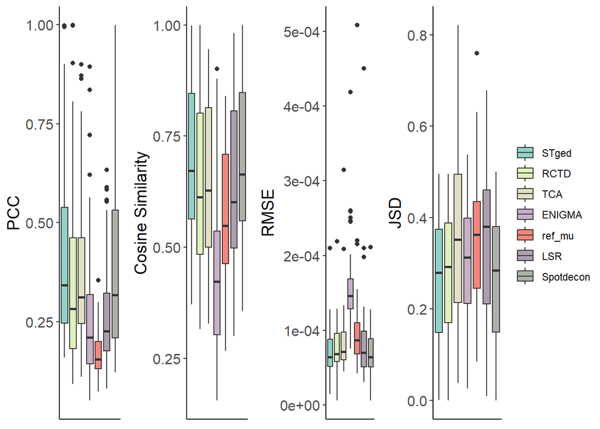

```r
plot_list  = list()
for ( i in  1:4){
  cellcorrs <- data.frame(corr = c(benmark_Res[,i,]),
                          methods = factor(rep(methods_name, each = dim(benmark_Res)[1]),
                                           levels =  methods_name ))

  plot_list[[i]]<- ggplot(cellcorrs,  aes(x =methods, y = corr))+
    geom_boxplot()+ aes(fill = methods)+
    labs(x=" ", y= eva.ind[i]) + theme_classic()+
    theme(
      axis.text.x.bottom = element_blank(),
      axis.ticks.x  = element_blank(),
      axis.text.y.left = element_text(size = 12),
      axis.title.x = element_blank(),
      axis.title.y = element_text(size = 14),
      plot.title = element_text( size=14,hjust = 0.5),
      legend.title = element_blank(),
      panel.grid.major = element_blank(),
      panel.grid.minor = element_blank(),
      panel.border = element_blank(),
      axis.line = element_line(colour = "black")
    )+
    scale_fill_manual(values=colors)

}

pfig = ggpubr::ggarrange( plotlist  = plot_list , nrow = 1, ncol = 4,
                          common.legend = TRUE, legend = "right")

pfig
```

*Notes:* Comparison of Gene Expression with Cell Type Proportions from Proposed Cell Type Deconvolution Methods

```r
method.com = readRDS("./FISH+/EST_spot_decon.RDS")
```

```r
method.com.new = method.com[c(1,5:10)]
methods_name = names(method.com.new)
methods_name
```

```
## [1] "STged"     "RCTD"      "TCA"       "ENIGMA"    "ref_mu"    "LSR"
## [7] "Spotdecon"
```

```r
eva.metric.new = matrix(list(),length(methods_name),1)
names(eva.metric.new) = methods_name


col_df <- data.frame(cell_types = methods_name,
                     col_vector = colors[1:length(methods_name)])
```

```r
for(i in 1:length(methods_name)){

  est_cte = res_library_size_normaization(estres = method.com.new[[i]],depthscale = 1,log =FALSE)

  eva.metric.new[[i]] = corr.cal.spot(F.est = est_cte, F.true = Truef.norm, beta.ind )

}

eva.ind = c("PCC", "Cosine Similarity","RMSE","JSD")

benmark_Res = abind::abind(eva.metric.new, along = 3)

mean_R <- apply(benmark_Res, c(2, 3), median,na.rm = TRUE)

rownames(mean_R) = eva.ind
colnames(mean_R) = methods_name
mean_R[,methods_name]
```

```
##                         STged         RCTD         TCA       ENIGMA
## PCC               0.342462663 2.964627e-01 0.229767876 0.1535990055
## Cosine Similarity 0.668484258 6.022403e-01 0.451049776 0.3480737923
## RMSE              0.000064651 6.928261e-05 0.000106054 0.0001692488
## JSD               0.281102268 2.944983e-01 0.752699153 0.3550783761
##                         ref_mu          LSR    Spotdecon
## PCC               1.550711e-01 1.484468e-01 3.173752e-01
## Cosine Similarity 5.482353e-01 5.027332e-01 6.643023e-01
## RMSE              8.645197e-05 8.469463e-05 6.395059e-05
## JSD               3.630483e-01 5.953012e-01 2.846627e-01
```

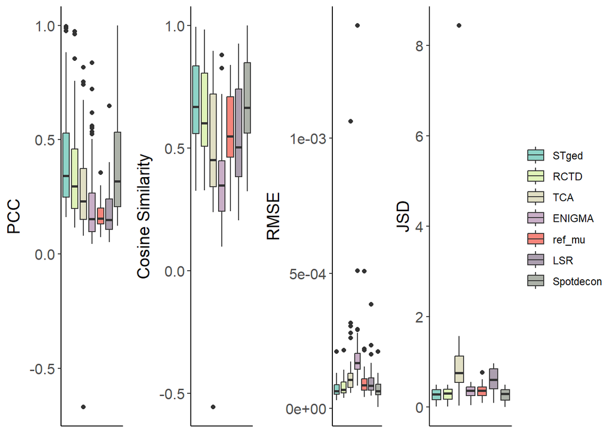

```r
plot_list  = list()
for ( i in  1:4){
  cellcorrs <- data.frame(corr = c(benmark_Res[,i,]),
                          methods = factor(rep(methods_name, each = dim(benmark_Res)[1]),
                                           levels =  methods_name ))

  plot_list[[i]]<- ggplot(cellcorrs,  aes(x =methods, y = corr))+
    geom_boxplot()+ aes(fill = methods)+
    labs(x=" ", y= eva.ind[i]) + theme_classic()+
    theme(
      axis.text.x.bottom = element_blank(),
      axis.ticks.x  = element_blank(),
      axis.text.y.left = element_text(size = 12),
      axis.title.x = element_blank(),
      axis.title.y = element_text(size = 14),
      plot.title = element_text( size=14,hjust = 0.5),
      legend.title = element_blank(),
      panel.grid.major = element_blank(),
      panel.grid.minor = element_blank(),
      panel.border = element_blank(),
      axis.line = element_line(colour = "black")
    )+
    scale_fill_manual(values=colors)

}

pfig = ggpubr::ggarrange( plotlist  = plot_list , nrow = 1, ncol = 4,
                          common.legend = TRUE, legend = "right")

pfig
```

# Compararation with true cell type proportion

```r
method.com = readRDS("./FISH+/TRUE_spot_decon.RDS")
names(method.com)
```

```
##  [1] "STged"      "STged.reg1" "STged.reg2" "STged.reg3" "RCTD"
##  [6] "TCA"        "ENIGMA"     "ref_mu"     "LSR"        "Spotdecon"
```

## ablation experiements

```r
compar = method.com[c(1:4)]
names(compar)
```

```
## [1] "STged"      "STged.reg1" "STged.reg2" "STged.reg3"
```

```r
methods_name = names(compar)
eva.metric.new = matrix(list(),length(methods_name),1)
names(eva.metric.new) = methods_name
methods_name
```

```
## [1] "STged"      "STged.reg1" "STged.reg2" "STged.reg3"
```

```r
for(i in 1:length(methods_name)){

  est_cte = res_library_size_normaization(estres = compar[[i]],depthscale = 1,log =FALSE)

  eva.metric.new[[i]] = corr.cal.spot(F.est = est_cte, F.true = Truef.norm, beta.ind )

}
```

```r
eva.ind = c("PCC", "Cosine Similarity","RMSE","JSD")

benmark_Res = abind::abind(eva.metric.new, along = 3)

mean_R <- apply(benmark_Res, c(2, 3), median,na.rm = TRUE)

rownames(mean_R) = eva.ind
colnames(mean_R) = methods_name
mean_R[,methods_name]
```

```
##                          STged   STged.reg1   STged.reg2   STged.reg3
## PCC               3.424457e-01 3.403289e-01 3.324232e-01 3.191421e-01
## Cosine Similarity 6.718883e-01 6.697994e-01 6.682501e-01 6.648499e-01
## RMSE              6.414661e-05 6.389684e-05 6.387707e-05 6.405376e-05
## JSD               2.794959e-01 2.802036e-01 2.818494e-01 2.840290e-01
```

```r
col_df <- data.frame(cell_types = methods_name,
                     col_vector = colors[1:length(methods_name)])
```

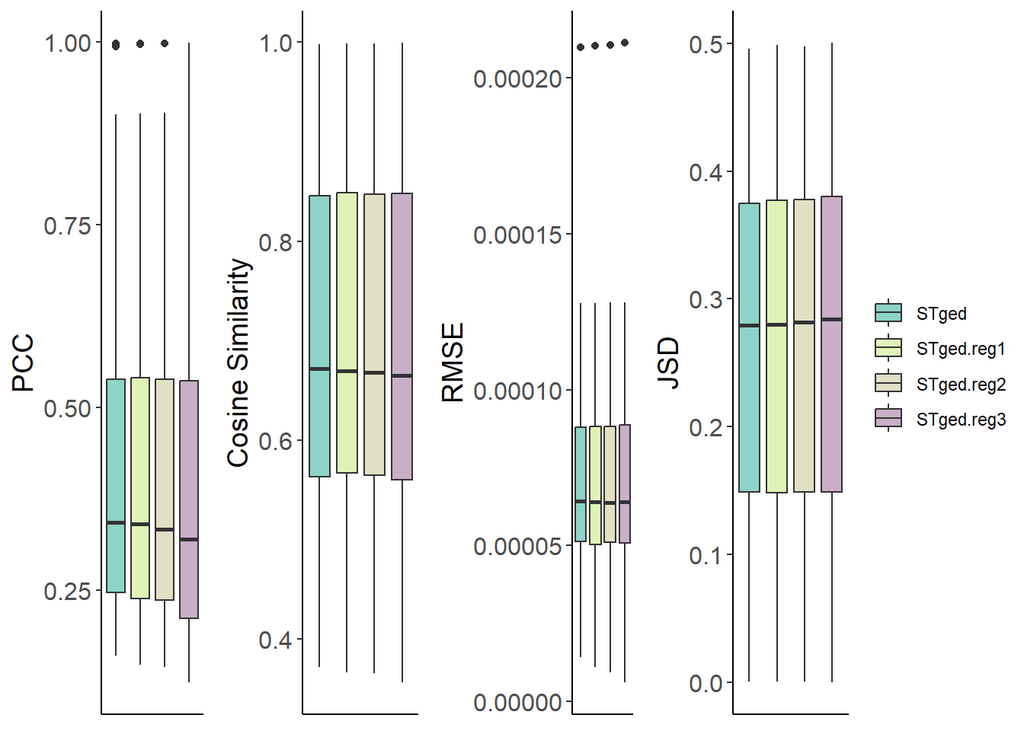

```r
plot_list  = list()
for ( i in  1:4){
  cellcorrs <- data.frame(corr = c(benmark_Res[,i,]),
                          methods = factor(rep(methods_name, each = dim(benmark_Res)[1]),
                                           levels =  methods_name ))

  plot_list[[i]]<- ggplot(cellcorrs,  aes(x =methods, y = corr))+
    geom_boxplot()+ aes(fill = methods)+
    labs(x=" ", y= eva.ind[i]) + theme_classic()+
    theme(
      axis.text.x.bottom = element_blank(),
      axis.ticks.x  = element_blank(),
      axis.text.y.left = element_text(size = 12),
      axis.title.x = element_blank(),
      axis.title.y = element_text(size = 14),
      plot.title = element_text( size=14,hjust = 0.5),
      legend.title = element_blank(),
      panel.grid.major = element_blank(),
      panel.grid.minor = element_blank(),
      panel.border = element_blank(),
      axis.line = element_line(colour = "black")
    )+
    scale_fill_manual(values=colors)

}

pfig = ggpubr::ggarrange( plotlist  = plot_list , nrow = 1, ncol = 4,
                          common.legend = TRUE, legend = "right")

pfig
```

## gene level analysis

```r
for(i in 1:length(methods_name)){

  est_cte = res_library_size_normaization(estres = method.com.new[[i]],depthscale = 1,log =FALSE)

  eva.metric.new[[i]] = corr.cal.gene(F.est = est_cte, F.true = Truef.norm, beta.ind )

}
eva.ind = c("PCC", "Cosine Similarity","RMSE","JSD")

  benmark_Res = abind::abind(eva.metric.new, along = 3)

  mean_R <- apply(benmark_Res, c(2, 3), median)

  rownames(mean_R) = eva.ind
  colnames(mean_R) = methods_name
  mean_R[,methods_name]
```

```
##                          STged   STged.reg1   STged.reg2   STged.reg3
## PCC               0.2502858126 0.2491347140 0.1141213791 0.2141353996
## Cosine Similarity 0.5920846417 0.5798834004 0.3890003085 0.5169846188
## RMSE              0.0002076198 0.0002186023 0.0002933737 0.0002406134
## JSD               0.3295237975 0.3217199994 0.6237629643 0.3391821059
```

```r
genes =  rownames(Truef.norm[[1]])

LRs = readRDS("./realdata/LR_analysis/lr_network_mouse_21122021.rds")
LRs_gene = c(unique(c(LRs$from,LRs$to)))

#LRs_gene = intersect(LRs_gene)
LRs_gene_sec = intersect(LRs_gene, genes)
other_gene = setdiff(genes, LRs_gene_sec)
length(LRs_gene_sec)
```

```
## [1] 492
```

```r
length(other_gene)
```

```
## [1] 5979
```

```r
eva.ind <- c("PCC", "Cosine Similarity","RMSE","JSD")
names(eva.metric.new)
```

```
## [1] "STged"      "STged.reg1" "STged.reg2" "STged.reg3"
```

```r
benmark_Res = abind::abind(eva.metric.new, along = 3)


dimnames(benmark_Res) <- list(Gene = genes,
                              Metric = eva.ind,
                              Method = methods_name)


mean_R1 <- apply(benmark_Res[LRs_gene_sec,,], c(2, 3), median)
mean_R2 <- apply(benmark_Res[other_gene,,], c(2, 3), median)

mean_R1
```

```
##                    Method
## Metric                     STged   STged.reg1   STged.reg2   STged.reg3
##   PCC               0.2683817408 0.2615697975 0.1236611882 0.2339392778
##   Cosine Similarity 0.5917547669 0.5657617101 0.3833859112 0.5033079765
##   RMSE              0.0002142994 0.0002478053 0.0003124027 0.0002702773
##   JSD               0.3296916735 0.3309199628 0.6534479644 0.3472987849
```

```r
mean_R2
```

```
##                    Method
## Metric                     STged   STged.reg1   STged.reg2   STged.reg3
##   PCC               0.2487296724 0.2483880475 0.1133534952 0.2123371092
##   Cosine Similarity 0.5921763125 0.5805620684 0.3896840935 0.5174789451
##   RMSE              0.0002071552 0.0002167313 0.0002922775 0.0002386452
##   JSD               0.3295237975 0.3211791673 0.6213473231 0.3385858593
```

```r
# Extract the subset of benmark_Res for LRs_gene_sec and other_gene
benmark_R1 <- benmark_Res[LRs_gene_sec, , ]
benmark_R2 <- benmark_Res[other_gene, , ]

# Convert the arrays to data frames for R1 and R2
benmark_R1_df <- as.data.frame(as.table(benmark_R1))
benmark_R2_df <- as.data.frame(as.table(benmark_R2))

# Add a column to distinguish R1 (LRs_gene_sec) and R2 (other_gene)
benmark_R1_df$GeneSet <- "LRs"
benmark_R2_df$GeneSet <- "Other genes"

# Combine the data frames
benmark_combined_df <- rbind(benmark_R1_df, benmark_R2_df)

# Rename the columns to be more informative
colnames(benmark_combined_df) <- c("Gene", "Metric", "Method", "Value", "GeneSet")

# Convert GeneSet to a factor to control the order in the plot
benmark_combined_df$GeneSet <- factor(benmark_combined_df$GeneSet, levels = c("LRs", "Other genes"))
```

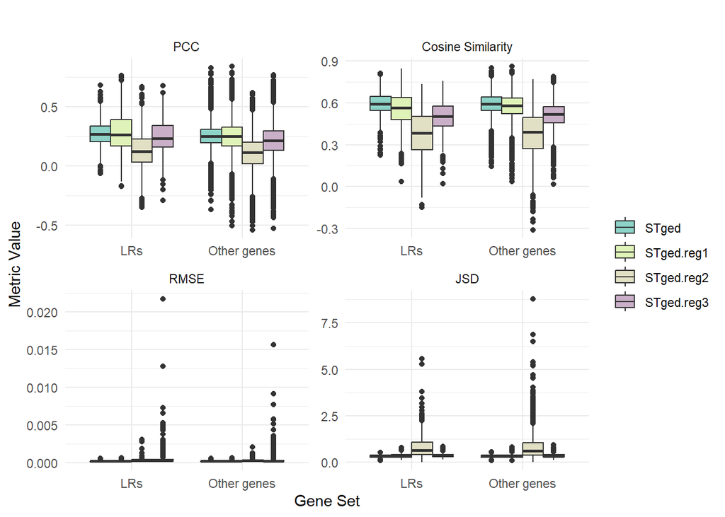

```r
# Create boxplots comparing LRs_gene_sec and other_gene across methods and metrics
p1 = ggplot(benmark_combined_df, aes(x = GeneSet, y = Value, fill = Method)) +
  geom_boxplot(position = position_dodge(width = 0.75)) +
  facet_wrap(~ Metric, scales = "free") +  # Create subfigures for each evaluation metric
  labs(title = "",
       x = "Gene Set",
       y = "Metric Value") +
  theme_minimal()+
  theme(legend.position = "right",
  legend.title = element_blank()
  )+
  scale_fill_manual(values=colors)

p1
```

## Benchmarking of cell type proportion

## cell tyep deconvolution benchmark

```r
method.com = readRDS("./FISH+/STged_est_spot_decon_tuning.RDS")

res_decon_ct = readRDS("./realdata/FISH+/EnDecon_major/FISH_Results.Deconv.RDS")

names(method.com) = names(res_decon_ct)
method.com.new = method.com[c(7,1,6,8,2,9)]
methods = names(method.com.new)
methods
```

```
## [1] "EnDecon"       "CARD"          "cell2location" "DWLS"
## [5] "RCTD"          "SONAR"
```

```r
eva.metric.new = matrix(list(), length(methods) ,1)
names(eva.metric.new) = methods

for(ii in 1: length(methods) ){

  cat("Run the STged", methods[ii], "\n")
  ##spot-level analysis
  bench_celltype_STged_est = res_library_size_normaization(estres = method.com.new[[ii]], depthscale = 1,log = FALSE)
  eva.metric.new[[ii]] = corr.cal.spot(F.est = bench_celltype_STged_est, F.true =Truef.norm, beta.ind )
}
```

```
## Run the STged EnDecon
## Run the STged CARD
## Run the STged cell2location
## Run the STged DWLS
## Run the STged RCTD
## Run the STged SONAR
```

```r
eva.ind = c("PCC", "Cosine Similarity","RMSE","JSD")

benmark_Res = abind::abind(eva.metric.new, along = 3)

mean_R <- apply(benmark_Res, c(2, 3), median,na.rm = TRUE)

mean_R
```

```
##           EnDecon         CARD cell2location         DWLS         RCTD
## [1,] 3.449622e-01 3.143234e-01  3.410239e-01 3.236054e-01 3.478416e-01
## [2,] 6.712274e-01 6.599610e-01  6.666381e-01 6.589194e-01 6.720952e-01
## [3,] 6.482345e-05 6.535711e-05  6.770461e-05 6.742964e-05 6.466287e-05
## [4,] 2.805198e-01 2.921452e-01  2.822584e-01 2.923780e-01 2.802917e-01
##             SONAR
## [1,] 3.480428e-01
## [2,] 6.721155e-01
## [3,] 6.470157e-05
## [4,] 2.802862e-01
```

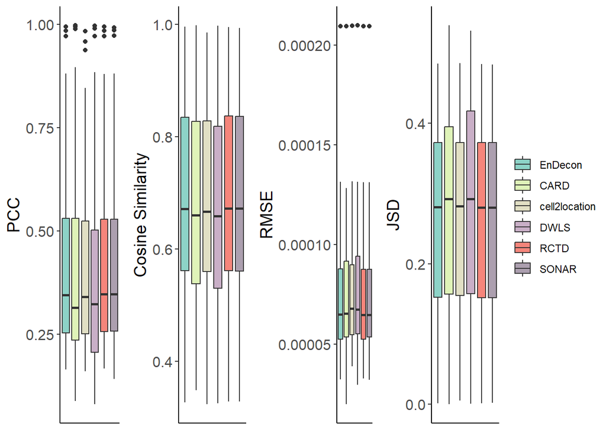

```r
plot_list  = list()
for ( i in  1:4){
  cellcorrs <- data.frame(corr = c(benmark_Res[,i,]),
                          methods = factor(rep(methods, each = dim(benmark_Res)[1]),
                                           levels =  methods))

  plot_list[[i]]<- ggplot(cellcorrs,  aes(x =methods, y = corr))+
    geom_boxplot()+ aes(fill = methods)+
    labs(x=" ", y= eva.ind[i]) + theme_classic()+
    theme(
      axis.text.x.bottom = element_blank(),
      axis.ticks.x =  element_blank(),
      axis.text.y.left = element_text(size = 12),
      axis.title.x = element_blank(),
      axis.title.y = element_text(size = 14),
      plot.title = element_text( size=14,hjust = 0.5),
      legend.title = element_blank(),
      panel.grid.major = element_blank(),
      panel.grid.minor = element_blank(),
      panel.border = element_blank(),
      axis.line = element_line(colour = "black")
    )+
    scale_fill_manual(values=colors)

}


pfig = ggpubr::ggarrange( plotlist  = plot_list , nrow = 1, ncol = 4,
                          common.legend = TRUE, legend = "right")

pfig
```

## Tuning Parameter Sensitivity Analysis

```r
STged = readRDS("./FISH+/True_spot_decon_sens_VAR.RDS")

parameter_grid = readRDS("./FISH+/True_cell_exp_tuning_values_VAR.RDS")
```

## spot-level analysis

```r
eva.metric.new = matrix(list(),nrow(parameter_grid ),1)

for(i in 1:nrow(parameter_grid )){

  est_cte = res_library_size_normaization(estres = STged[[i]],depthscale = 1,log =FALSE)

  eva.metric.new[[i]] = corr.cal.spot(F.est = est_cte, F.true = Truef.norm, beta.ind )

}


  eva.ind = c("PCC", "Cosine Similarity","RMSE","JSD")

  benmark_Res = abind::abind(eva.metric.new, along = 3)

  mean_R <- apply(benmark_Res, c(2, 3), median)
```

### Draw the heatmap figures

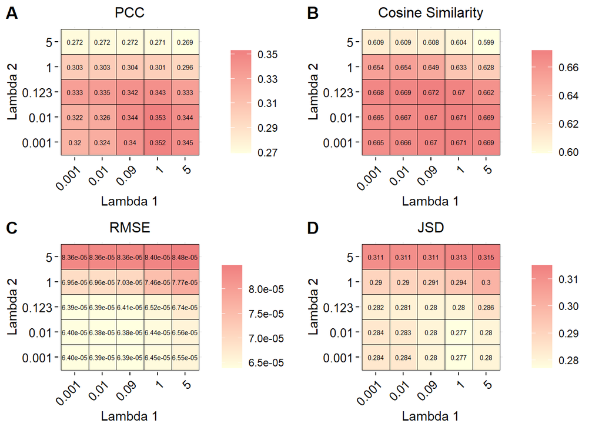

```r
df <- as.data.frame(t(mean_R))
df$V1 <- sprintf("%.3f", df$V1)
df$V2 <- sprintf("%.3f", df$V2)
df$V3 <- sprintf("%.4e", df$V3)
df$V4 <- sprintf("%.3f", df$V4)


title_name <- c("PCC", "Cosine Similarity", "RMSE","JSD")


pp <- vector("list", length = 4)


for(i in 1:4){
  data_frame <- parameter_grid
  data_frame$Value <- as.numeric(df[,i])

  if(i != 3){

    pp[[i]] <- ggplot(data_frame, aes(x = as.character(lambda1),
                                      y = as.character(lambda2), fill = Value, label = Value)) +
      geom_tile(color = "black") +
      geom_text(size = 2, color = "black") +
      scale_fill_gradient(low = "lightyellow", high = "lightcoral") +
      labs(
        x = "Lambda 1",
        y = "Lambda 2",
        fill = "Value",
        title = title_name[i]
      ) +  labs(fill = "") +
      theme_minimal() +
      theme(
        plot.title = element_text(color = "black", size = 12, hjust = 0.5),
        axis.text.x = element_text(angle = 45, size = 10, hjust = 1, color = "black"),
        axis.text.y = element_text(size = 10, hjust = 1, color = "black"),
        axis.title.x = element_text(size = 11, color = "black", hjust = 0.5),
        axis.title.y = element_text(size = 11, color = "black", hjust = 0.5),
        axis.ticks = element_line(color = "black")
      )
  } else {

    pp[[i]] <- ggplot(data_frame, aes(x = as.character(lambda1),
                                      y = as.character(lambda2), fill = Value, label = sprintf("%.2e", Value))) +
      geom_tile(color = "black") +
      geom_text(color = "black", size = 2) +
      scale_fill_gradient(low = "lightyellow", high = "lightcoral") +
      labs(
        x = "Lambda 1",
        y = "Lambda 2",
        fill = "Value",
        title = title_name[i]
      ) +  labs(fill = "") +
      theme_minimal() +
      theme(
        plot.title = element_text(color = "black", size = 12, hjust = 0.5),
        axis.text.x = element_text(angle = 45, size = 10, hjust = 1, color = "black"),
        axis.text.y = element_text(size = 10, hjust = 1, color = "black"),
        axis.title.x = element_text(size = 11, color = "black", hjust = 0.5),
        axis.title.y = element_text(size = 11, color = "black", hjust = 0.5),
        axis.ticks = element_line(color = "black")
      )
  }
}

pp1 <- cowplot::plot_grid(plotlist = pp, labels = "AUTO", nrow = 2, align = "v")
print(pp1)
```